# project v4

#### Models with no overfitting

```python
a = list(np.arange(1,score_df.shape[1],2))

x=score_df.T.iloc[a]
x = x[x.model_accuracy<=0.98]
display(x)

no_overf_models = list(x.index)
print(no_overf_models)
```

|  | model_accuracy | model_recall_sensitivity_TPR | model_precision | Specificity_TNR | model_f1 | FPR |
| --- | --- | --- | --- | --- | --- | --- |
| DT-tuned-train | 0.841813 | 0.251944 | 0.729730 | 0.978394 | 0.374566 | 0.021606 |
| ABC-train | 0.853801 | 0.346812 | 0.735974 | 0.971192 | 0.471459 | 0.028808 |
| GBC-train | 0.888889 | 0.482115 | 0.868347 | 0.983075 | 0.620000 | 0.016925 |
| GBC-tuned-train | 0.925731 | 0.639191 | 0.949192 | 0.992078 | 0.763941 | 0.007922 |
| XGB-tuned-train | 0.969883 | 0.846034 | 0.992701 | 0.998560 | 0.913518 | 0.001440 |

```
['DT-tuned-train', 'ABC-train', 'GBC-train', 'GBC-tuned-train', 'XGB-tuned-train']
```

```python
b=[]
for a in no_overf_models:
    b.append(a.replace('train', 'test'))

score_df.T.loc[b]
```

|  | model_accuracy | model_recall_sensitivity_TPR | model_precision | Specificity_TNR | model_f1 | FPR |
| --- | --- | --- | --- | --- | --- | --- |
| DT-tuned-test | 0.837653 | 0.229091 | 0.707865 | 0.978170 | 0.346154 | 0.021830 |
| ABC-test | 0.852660 | 0.316364 | 0.756522 | 0.976490 | 0.446154 | 0.023510 |
| GBC-test | 0.872442 | 0.396364 | 0.838462 | 0.982368 | 0.538272 | 0.017632 |
| GBC-tuned-test | 0.884720 | 0.498182 | 0.815476 | 0.973971 | 0.618510 | 0.026029 |
| XGB-tuned-test | 0.903820 | 0.552727 | 0.894118 | 0.984887 | 0.683146 | 0.015113 |

## Business implications

### Best Model

Models that do not overfit on training data are: DT-tuned, ABC, GBC, GBC tuned, and XGB tuned (defined as accuracy on train less than 0.98 - we note that for these models where accuracy >0.98, divergence between accuracy on test/ train data is quite large which also indicates overfitting)

Of these, both the Gradient and XGBoost models do well when tuned - the XGB-tuned may be slightly overfitting based on high accuracy and ~6% more accuracy on train vs. test, but otherwise does quite well

GBC-tuned also does well and no overfitting

### Best Features

While features are different for both models, most imp features are:

GBC-tuned: monthly income, age, passport, duration, prodpitched, marital, number of followups, city tier, no of trips

XGB-tuned: ProdPitched,passport, marital status, citytier, no of followups, prep prop star, age

### Metrics

Since dont want to waste marketing spend on likely negatives, precision is the important metric (of the trues model predicted, how many were actually positive)

having said that recall is imp too as dont want to miss likely positives

F1 score helps provide a balanced view between precision and recall

GBC tuned and XGB tuned do well on precision and F1 and are the best even for recall (ignoring overfitting models)

### Output if we dont drop rows with occupation=Free Lancer

We can see there is not much difference by dropping Free Lancer (except DT-tuned for recall and precision but anyway that is not our best model; for GBC tuned and XGB tuned we get similar performance)

#### Output with Data including Occupation=Free Lancer

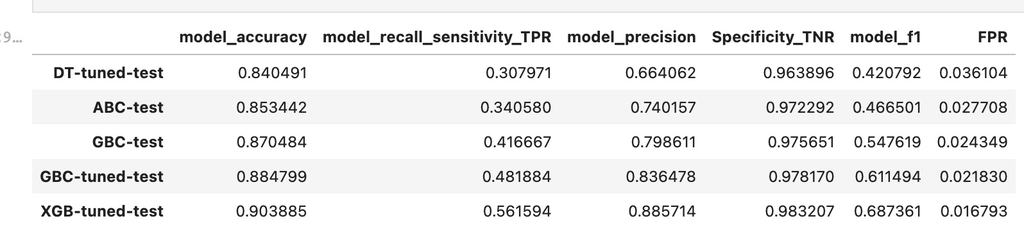